# Process Boston Data to find most Influencing Features

- output: html_notebook
- Author: shasibhusan
- Read required Packages

```r
library(corrplot)
library(ggplot2)
library(tidyverse)
library(corrplot)
library(car)
```

- Below are features types and use
- crime per capita crime rate by town.
- zn proportion of residential land zoned for lots over 25,000 sq.ft.
- indus proportion of non-retail business acres per town.
- chas Charles River dummy variable (= 1 if tract bounds river; 0 otherwise).
- nox nitrogen oxides concentration (parts per 10 million).
- rm average number of rooms per dwelling.
- age proportion of owner-occupied units built prior to 1940.
- dis weighted mean of distances to five Boston employment centres.
- rad index of accessibility to radial highways.
- tax full-value property-tax rate per $10,000.
- ptratio pupil-teacher ratio by town.
- black 1000(Bk - 0.63)^2 where Bk is the proportion of blacks by town.
- lstat lower status of the population (percent).
- medv median value of owner-occupied homes in $1000s.
- Read Boston data Set using Mass Pkg

```r
data(package='MASS')
data('Boston')
str(Boston)
```

```
'data.frame':   506 obs. of  14 variables:
 $ crim   : num  0.00632 0.02731 0.02729 0.03237 0.06905 ...
 $ zn     : num  18 0 0 0 0 0 12.5 12.5 12.5 12.5 ...
 $ indus  : num  2.31 7.07 7.07 2.18 2.18 2.18 7.87 7.87 7.87 7.87 ...
 $ chas   : int  0 0 0 0 0 0 0 0 0 0 ...
 $ nox    : num  0.538 0.469 0.469 0.458 0.458 0.458 0.524 0.524 0.524 0.524 ...
 $ rm     : num  6.58 6.42 7.18 7 7.15 ...
 $ age    : num  65.2 78.9 61.1 45.8 54.2 58.7 66.6 96.1 100 85.9 ...
 $ dis    : num  4.09 4.97 4.97 6.06 6.06 ...
 $ rad    : int  1 2 2 3 3 3 5 5 5 5 ...
 $ tax    : num  296 242 242 222 222 222 311 311 311 311 ...
 $ ptratio: num  15.3 17.8 17.8 18.7 18.7 18.7 15.2 15.2 15.2 15.2 ...
 $ black  : num  397 397 393 395 397 ...
 $ lstat  : num  4.98 9.14 4.03 2.94 5.33 ...
 $ medv   : num  24 21.6 34.7 33.4 36.2 28.7 22.9 27.1 16.5 18.9 ...
```

```r
## Setting any name change
names(Boston) = c('crim','zn','indus','chas','nox','rm','age','dis','rad','tax','ptratio','black','lstat','medv')
attach(Boston)
```

- Find multi collinearity

```r
M = cor(Boston)
head(round(M,2))
```

```
       crim    zn indus  chas   nox    rm   age   dis   rad   tax ptratio black lstat  medv
crim   1.00 -0.20  0.41 -0.06  0.42 -0.22  0.35 -0.38  0.63  0.58    0.29 -0.39  0.46 -0.39
zn    -0.20  1.00 -0.53 -0.04 -0.52  0.31 -0.57  0.66 -0.31 -0.31   -0.39  0.18 -0.41  0.36
indus  0.41 -0.53  1.00  0.06  0.76 -0.39  0.64 -0.71  0.60  0.72    0.38 -0.36  0.60 -0.48
chas  -0.06 -0.04  0.06  1.00  0.09  0.09  0.09 -0.10 -0.01 -0.04   -0.12  0.05 -0.05  0.18
nox    0.42 -0.52  0.76  0.09  1.00 -0.30  0.73 -0.77  0.61  0.67    0.19 -0.38  0.59 -0.43
rm    -0.22  0.31 -0.39  0.09 -0.30  1.00 -0.24  0.21 -0.21 -0.29   -0.36  0.13 -0.61  0.70
```

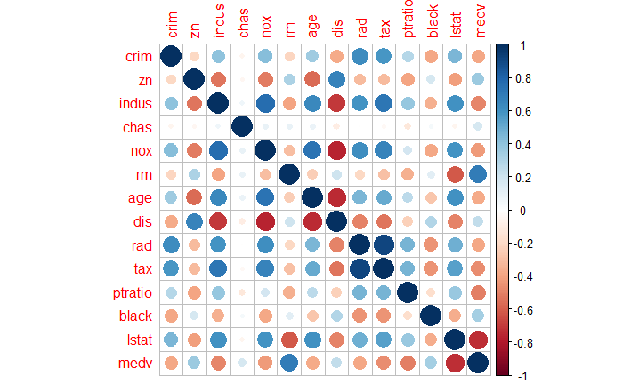

```r
cor.mtest =function(mat) {
  mat = as.matrix(mat)
  n = ncol(mat)
  p.mat= matrix(NA, n, n)
  diag(p.mat) = 0

  for (i in 1:(n - 1)) {
    for (j in (i + 1):n) {
      # loopval =   paste('i=',i,'j=',j)
      # print(loopval)
      tmp = cor.test(mat[, i], mat[, j])
      p.mat[i, j] = p.mat[j, i] = tmp$p.value
    }
  }
  colnames(p.mat) = rownames(p.mat) = colnames(mat)
  p.mat
}
p.mat=cor.mtest(Boston)

corrplot(M, method = 'circle')
```

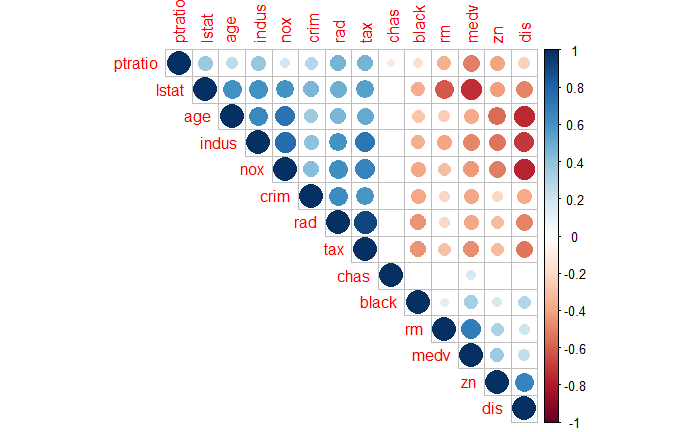

```r
# Leave blank on no significant coefficient
corrplot(M, type="upper", order="hclust", p.mat = p.mat, sig.level = 0.01, insig = "blank")
```

- Linear Regression Model building
- Running model and checking for significant *** features

```r
str(Boston)
```

```
'data.frame':   506 obs. of  14 variables:
 $ crim   : num  0.00632 0.02731 0.02729 0.03237 0.06905 ...
 $ zn     : num  18 0 0 0 0 0 12.5 12.5 12.5 12.5 ...
 $ indus  : num  2.31 7.07 7.07 2.18 2.18 2.18 7.87 7.87 7.87 7.87 ...
 $ chas   : int  0 0 0 0 0 0 0 0 0 0 ...
 $ nox    : num  0.538 0.469 0.469 0.458 0.458 0.458 0.524 0.524 0.524 0.524 ...
 $ rm     : num  6.58 6.42 7.18 7 7.15 ...
 $ age    : num  65.2 78.9 61.1 45.8 54.2 58.7 66.6 96.1 100 85.9 ...
 $ dis    : num  4.09 4.97 4.97 6.06 6.06 ...
 $ rad    : int  1 2 2 3 3 3 5 5 5 5 ...
 $ tax    : num  296 242 242 222 222 222 311 311 311 311 ...
 $ ptratio: num  15.3 17.8 17.8 18.7 18.7 18.7 15.2 15.2 15.2 15.2 ...
 $ black  : num  397 397 393 395 397 ...
 $ lstat  : num  4.98 9.14 4.03 2.94 5.33 ...
 $ medv   : num  24 21.6 34.7 33.4 36.2 28.7 22.9 27.1 16.5 18.9 ...
```

```r
# Bulding with all attributes, to find most influecning feature
salesLM_all = lm(medv ~ zn+nox+rm+dis+rad+ptratio+black ,data = Boston)
summary(salesLM_all)
```

```
Call:
lm(formula = medv ~ zn + nox + rm + dis + rad + ptratio + black,
    data = Boston)

Residuals:
   Min     1Q Median     3Q    Max
-15.01  -2.70  -0.45   2.11  37.09

Coefficients:
             Estimate Std. Error t value Pr(>|t|)
(Intercept)  15.36102    5.57830    2.75   0.0061 **
zn            0.02755    0.01536    1.79   0.0735 .
nox         -27.09309    3.88376   -6.98  9.7e-12 ***
rm            6.67130    0.39471   16.90  < 2e-16 ***
dis          -1.14593    0.21206   -5.40  1.0e-07 ***
rad           0.03201    0.04243    0.75   0.4510
ptratio      -1.19076    0.14704   -8.10  4.3e-15 ***
black         0.01677    0.00303    5.52  5.3e-08 ***
---
Signif. codes:  0 ‘***’ 0.001 ‘**’ 0.01 ‘*’ 0.05 ‘.’ 0.1 ‘ ’ 1

Residual standard error: 5.51 on 498 degrees of freedom
Multiple R-squared:  0.646, Adjusted R-squared:  0.641
F-statistic:  130 on 7 and 498 DF,  p-value: <2e-16
```

- analysing data with different features and combinations

```r
salesLM_nox = lm(medv ~ nox ,data = Boston)
summary(salesLM_nox)
```

```
Call:
lm(formula = medv ~ nox, data = Boston)

Residuals:
   Min     1Q Median     3Q    Max
-13.69  -5.12  -2.16   2.96  31.31

Coefficients:
            Estimate Std. Error t value Pr(>|t|)
(Intercept)    41.35       1.81    22.8   <2e-16 ***
nox           -33.92       3.20   -10.6   <2e-16 ***
---
Signif. codes:  0 ‘***’ 0.001 ‘**’ 0.01 ‘*’ 0.05 ‘.’ 0.1 ‘ ’ 1

Residual standard error: 8.32 on 504 degrees of freedom
Multiple R-squared:  0.183, Adjusted R-squared:  0.181
F-statistic:  113 on 1 and 504 DF,  p-value: <2e-16
```

```r
salesLM_rm = lm(medv ~ rm , data = Boston)
summary(salesLM_rm)
```

```
Call:
lm(formula = medv ~ rm, data = Boston)

Residuals:
   Min     1Q Median     3Q    Max
-23.35  -2.55   0.09   2.99  39.43

Coefficients:
            Estimate Std. Error t value Pr(>|t|)
(Intercept)  -34.671      2.650   -13.1   <2e-16 ***
rm             9.102      0.419    21.7   <2e-16 ***
---
Signif. codes:  0 ‘***’ 0.001 ‘**’ 0.01 ‘*’ 0.05 ‘.’ 0.1 ‘ ’ 1

Residual standard error: 6.62 on 504 degrees of freedom
Multiple R-squared:  0.484, Adjusted R-squared:  0.483
F-statistic:  472 on 1 and 504 DF,  p-value: <2e-16
```

```r
salesLM_nox_rm = lm(medv  ~ nox + rm+ nox:rm, data = Boston)
summary(salesLM_nox_rm)
```

```
Call:
lm(formula = medv ~ nox + rm + nox:rm, data = Boston)

Residuals:
   Min     1Q Median     3Q    Max
-14.30  -3.23  -0.43   2.10  38.39

Coefficients:
            Estimate Std. Error t value Pr(>|t|)
(Intercept)  -113.37      12.07   -9.39  < 2e-16 ***
nox           146.47      20.40    7.18  2.5e-12 ***
rm             23.43       1.91   12.26  < 2e-16 ***
nox:rm        -26.75       3.28   -8.17  2.6e-15 ***
---
Signif. codes:  0 ‘***’ 0.001 ‘**’ 0.01 ‘*’ 0.05 ‘.’ 0.1 ‘ ’ 1

Residual standard error: 5.91 on 502 degrees of freedom
Multiple R-squared:  0.59,  Adjusted R-squared:  0.587
F-statistic:  241 on 3 and 502 DF,  p-value: <2e-16
```

- after removing un significant features building final model with below features
- nox,rm,dis,ptratio,black shows strong co relation.

```r
salesLM_all_after_cleanUP = lm(medv ~ nox+rm+dis+ptratio+black ,data = Boston)
summary(salesLM_all_after_cleanUP)
```

```
Call:
lm(formula = medv ~ nox + rm + dis + ptratio + black, data = Boston)

Residuals:
   Min     1Q Median     3Q    Max
-14.59  -2.85  -0.51   1.88  37.86

Coefficients:
             Estimate Std. Error t value Pr(>|t|)
(Intercept)  14.25915    5.30916    2.69   0.0075 **
nox         -25.78031    3.53348   -7.30  1.2e-12 ***
rm            6.81926    0.38900   17.53  < 2e-16 ***
dis          -0.95471    0.18531   -5.15  3.7e-07 ***
ptratio      -1.20756    0.12448   -9.70  < 2e-16 ***
black         0.01578    0.00293    5.38  1.1e-07 ***
---
Signif. codes:  0 ‘***’ 0.001 ‘**’ 0.01 ‘*’ 0.05 ‘.’ 0.1 ‘ ’ 1

Residual standard error: 5.52 on 500 degrees of freedom
Multiple R-squared:  0.643, Adjusted R-squared:  0.639
F-statistic:  180 on 5 and 500 DF,  p-value: <2e-16
```

- Vif The variance inflation factor (VIF) quantifies the extent of correlation between one predictor and the other predictors in a model.

```r
vif(salesLM_all)
```

```
     zn     nox      rm     dis     rad ptratio   black
   2.13    3.37    1.28    3.32    2.27    1.69    1.28
```

```r
vif(salesLM_all_after_cleanUP)
```

```
    nox      rm     dis ptratio   black
   2.78    1.24    2.52    1.20    1.19
```